# OpenGWASDB at full scale — OGS-00011

Published

November 25, 2026

The GWAS Catalog EUR Hybrid Store — 3,245 Analyses, Reference-Completed · 47.9 million variants and 49.0 billion associations

**ImportantWhat this measures**

One Store Release over the GWAS Catalog’s European-ancestry summary statistics, built once and queried through the public API.

The release is one Store with two physical components, and every query is answered from one or both of them:

- the **Dense Component** (`dense/`) holds a cell for each of the **14,564,257 panel variants** in each of the 3,245 Analyses that come from 497 publications — 47.3 billion cells on the reference axis, observed or filled in by Reference Completion;
- the **Ragged Overflow** (`data.zarr/ragged/`) holds, for each Analysis, the variants that Analysis observed off the panel: **33,356,475 distinct variants** carrying 1,709,877,306 associations, stored against a variant index rather than a dense axis;
- the **shared variant axis** (`variants.tsv.gz` and the ALID and rsid lookups) is what gives both components one address space.

A lookup of a panel variant reads the Dense Component. A lookup of an off-axis variant reads only the Overflow. A whole-Analysis read touches both and merges them in genomic order.

- **167.84 GB** on disk, against **1,546.58 GB** of source GWAS-SSF across 3,245 files — a **9.21×** reduction.
- A top-hits query returns in **18.3 ms**; a PheWAS across all 3,245 Analyses in **125.2 ms**; a PheWAS of an off-axis variant in **35.3 ms**.
- Those queries need **~284 MB** of resident memory. A laptop can open this Store.
- Build and Reference Completion took **40.70 h** of wall clock.

## Scope

| Property | Value |
| --- | --- |
| Store Release | OGS-00011 (Hybrid) |
| Completion state | Reference-Completed |
| Analyses | 3,245 from 497 publications |
| Variants | 47,920,732 |
| on the reference axis (panel) | 14,564,257 |
| off the axis (Overflow only) | 33,356,475 |
| Dense Component cells | 47,261,013,965 |
| Overflow associations | 1,709,877,306 |
| Associations in total | 48,970,891,271 |
| Reference assembly | GRCh38 |
| Store format version | `0.2.3` (encoding v3) |
| Encoding | z `int16_fixed` at 1/1024, se `float16`, eaf `int8_residual` over ±1 |
| Dense chunk shape | 1,000 × 64 |
| Panel (variant reference) | `/data/opengwasdb/reference/gnomad-v4-common-hg38-v2/EUR-variants.txt.gz` |
| Opening the Store | 0.63 s |

The panel is the Store’s recorded variant reference: gnomAD v4 common variants, filtered to its EUR set. It is the axis the Dense Component shares between Analyses, and the reason a variant that is not on it can only be answered from the Overflow.

| Measure | Value |
| --- | --- |
| Assigned ancestry | EUR 3,245 |
| Sample size (min / median / max) | 15 / 48,434 / 2,584,013 |
| Stored Effect Scale | `sd` 2,441, `log_or` 804 |
| EAF orientation | passed 3,244, unverified 1 |
| Hits at p < 5×10⁻⁸ | median 326, max 629,050; 708 Analyses have none, 29,071,967 in total |

## Storage

| Component | Bytes | Files |
| --- | --- | --- |
| Dense Component | 141.69 GB | 30,001 |
| Ragged Overflow | 21.92 GB | 437 |
| Shared variant axis | 4.23 GB | 11 |
| **Store Release, whole directory** | **167.84 GB** | **30,452** |

The three component rows are the harness’s own walk of each part of the release. Between them they account for all but 17,150 bytes of the 167,840,958,083 the whole directory holds. The Shared variant axis is 2.5% of the Store, and it is what makes the two components one address space rather than two files that happen to sit together.

| Measure | Value |
| --- | --- |
| Store Release | 167.84 GB across 30,452 files |
| Source GWAS-SSF | 1,546.58 GB across 3,245 files |
| Reduction | **9.21×** |
| Bytes per association | 3.43 B |

The source is already bgzip-compressed, so this is a reduction against compressed text, not against plain text. It comes from storing z and standard error as fixed-point and residual codes rather than as text floats, from encoding the allele frequency as a residual against the reference, and from holding the variant axis once instead of repeating positions and alleles in every Analysis.

## Build

| Step | Wall clock | opengwasdb | Workers | Started |
| --- | --- | --- | --- | --- |
| build | 19.96 h | `1230629a2c09` | 10 | 2026-11-22 |
| indexed-subset-hm3 | 19.2 min | `1230629a2c09` | — | 2026-11-23 |
| overview | 4 s | `1230629a2c09` | — | 2026-11-23 |
| validate | 41.0 min | `1230629a2c09` | 10 | 2026-11-23 |
| register | 0 s | `1230629a2c09` | — | 2026-11-23 |
| complete | 20.74 h | `1230629a2c09` | 24 | 2026-11-23 |
| completion-indexed-subset-hm3 | 22.9 min | `1230629a2c09` | — | 2026-11-24 |
| completion-overview | 4 s | `1230629a2c09` | — | 2026-11-24 |
| completion-validate | 39.1 min | `1230629a2c09` | 24 | 2026-11-24 |
| completion-observed-view-check | 3.37 h | `40446bb0ed47` | — | 2026-11-25 |
| completion-register | 0 s | `1230629a2c09` | — | 2026-11-25 |
| **All recorded steps** | **46.10 h** |  |  |  |

Each row carries the revision its step ran at, not one revision for the whole release: `1230629` for build, indexed-subset-hm3, overview, validate, register, complete, completion-indexed-subset-hm3, completion-overview, completion-validate, completion-register; `40446bb` for completion-observed-view-check. A Store built across a change of `opengwasdb` is still one Store, but its parts were written by different code, and the records here are where that shows.

## Query performance

The ten shapes below are the seven every full-scale benchmark times plus three the Hybrid layout needs. The selection is fixed across runs:

| Selection | Value |
| --- | --- |
| Analysis read whole (`bulk`) | `GCST006867` — Type 2 diabetes |
| Panel variant for the on-axis PheWAS | `10:112998590:C:T` (rs7903146, TCF7L2) |
| Window | chr10:112,500,000–113,500,000 (GRCh38) |
| Analysis with the largest Overflow | `GCST90274713` — Prostate cancer |
| Off-axis PheWAS variant | drawn from the shared axis with `default_rng(1)` |
| Random lookups | 10 variants × 100 Analyses; 100 variants × 10 Analyses |

The on-axis shapes are the ones the other full-scale releases time, so these numbers can be read beside those reports’. The off-axis PheWAS and the two whole-Analysis Overflow shapes have no counterpart in a Dense Store: they are the shapes the Hybrid layout exists for.

| Shape | Median | p95 | Reps | Rows returned |
| --- | --- | --- | --- | --- |
| Top hits for one Analysis (p < 5×10⁻⁸) | **18.3 ms** | 20.3 ms | 5 | 8,415 |
| One off-axis variant × every Analysis | **35.3 ms** | 36.3 ms | 5 | 15 |
| One panel variant × every Analysis | **125.2 ms** | 129.1 ms | 5 | 3,241 |
| 100 random variants × 10 Analyses | **1.09 s** | 1.11 s | 5 | 203 |
| 10 random variants × 100 Analyses | **1.57 s** | 2.62 s | 5 | 208 |
| A 1 Mb window × one Analysis | **2.88 s** | 4.69 s | 5 | 2,981 |
| A 1 Mb window × every Analysis | **3.08 s** | 3.22 s | 5 | 10,418,043 |
| One Analysis, genome-wide | **26.66 s** | 35.40 s | 5 | 9,812,661 |
| One Analysis, Dense Component alone | **27.32 s** | 30.19 s | 5 | 11,132,658 |
| One Analysis, genome-wide, both components | **34.52 s** | 40.44 s | 5 | 26,150,035 |

Every shape was timed 5 times after one warm-up call; a shape whose warm-up alone passed 60 s is timed once instead and says so in `Reps`, which none of these did. The span from the cheapest shape to the dearest is 1,887×, and it follows the size of the answer rather than a fixed cost per call: 8,415 rows against 26,150,035.

The four Dense-only twins the harness also times are not in this table. They ask four of these same questions of the Dense Component alone, and are set against their Hybrid calls under *Hybrid against its Dense Component* below.

### Hybrid against its Dense Component

| Question | Hybrid median | Hybrid rows | Dense-only median | Dense-only rows | Hybrid ÷ Dense-only |
| --- | --- | --- | --- | --- | --- |
| A 1 Mb window × every Analysis | **3.08 s** | 10,418,043 | **2.04 s** | 9,918,707 | 1.50× |
| A 1 Mb window × one Analysis | **2.88 s** | 2,981 | **109.1 ms** | 2,981 | 26.42× |
| 10 random variants × 100 Analyses | **1.57 s** | 208 | **766.4 ms** | 659 | 2.05× |
| 100 random variants × 10 Analyses | **1.09 s** | 203 | **2.01 s** | 621 | 0.55× |

A Hybrid lookup does more than a panel lookup, and the gap between the two sets of columns is what it charges for the difference. It resolves every identifier the call is given — variant ALIDs and rsids, and the Analyses it is asked about — on the shared axis of 47,920,732 variants; for a lookup of named Analyses it then searches each of those Analyses’ Ragged Overflow segments in turn. A regional PheWAS across every Analysis instead reads the Overflow’s by-variant index once, then merges the two components’ rows into one genomic order. The Dense-only column is the same question asked of the reference axis’ 14,564,257 panel variants and nothing else — the price a reader pays who wants panel variants only.

Bringing the one-Analysis window and the named-Analysis lookups close to their Dense-only twins is opengwas/opengwasdb#340: the identifier resolution is opengwas/opengwasdb#341 and the per-Analysis Overflow search opengwas/opengwasdb#342.

The seven questions this Store shares with OGS-00009, the release whose report these numbers can be read beside, have been timed there too — though not as a controlled comparison:

| Shared shape | OGS-00011 Hybrid | OGS-00009 Dense | Ratio |
| --- | --- | --- | --- |
| Top hits for one Analysis (p < 5×10⁻⁸) | 18.3 ms | 6.5 ms | 2.80× |
| One panel variant × every Analysis | 125.2 ms | 21.2 ms | 5.90× |
| A 1 Mb window × every Analysis | 3.08 s | 1.66 s | 1.85× |
| A 1 Mb window × one Analysis | 2.88 s | 51.3 ms | 56.23× |
| 10 random variants × 100 Analyses | 1.57 s | 97.8 ms | 16.08× |
| 100 random variants × 10 Analyses | 1.09 s | 572.1 ms | 1.91× |
| One Analysis, genome-wide | 26.66 s | 21.87 s | 1.22× |

OGS-00009’s numbers are the committed `opengwasdb_store_comparison_ogs00009_zarr3.json` (store `zarr3`), measured on 2026-10-05 (`measured_at`). The selections and the data differ: 2,024 Analyses against 3,245, 9,847,701 variants against 47,920,732, a chr19:44,500,000– 45,500,000 window against chr10:112,500,000– 113,500,000, `ukb-b-17805` instead of `GCST006867` as the whole-Analysis read, and a Store in the `observed_only` state against a `reference_completed` one. The table therefore shows orders of magnitude, not a controlled comparison: the one-Analysis window and the 10 × 100 lookup stand out, and the Dense-only twins above show how much of that is the Hybrid’s own work.

### The three Hybrid-only shapes

- **PheWAS of an off-axis variant** — 35.3 ms for 15 rows. The variant is off the reference axis, so the Dense Component holds no row for it and the entire answer comes from the Ragged Overflow: its variant-centric index maps the variant to the 15 Analyses that observed it, without reading the other 3,230. A Dense-of-union layout would hold that variant as a row in all 3,245 columns, almost all of it padding.
- **Whole Analysis through both components** — 34.52 s for 26,150,035 rows. The Hybrid facade reads the Analysis’s Dense Component column, reads its Overflow segment, and merges the two in genomic order: 11,132,658 rows from the panel and 15,017,377 from the Overflow.
- **Whole Analysis from the Dense Component alone** — 27.32 s for 11,132,658 rows. This is the control that isolates the Dense path, whose EAF column carries many exception-table cells, so the difference between it and the shape above is what the Overflow costs: 7.20 s and 15,017,377 rows.

### HM3 extraction

| Measure | Value |
| --- | --- |
| Subset | `hm3` (status `measured`) |
| Extracted for | `GCST006867` — Type 2 diabetes |
| Variants requested / resolved / absent | 1,206,903 / 1,195,931 / 152 |
| Subset holds | 1,195,931 variants × 3,245 Analyses |
| First read | 842.9 ms |
| Median | **712.2 ms** over 5 repetitions |
| p95 | 786.3 ms |
| Rows returned | 1,188,389 |
| Subset reference assembly | hg38 |
| Subset input SHA-256 | `4a7c82aa625a006f…` |

The Indexed Variant Subset is one Analysis’s statistics restricted to the HapMap3 variants — a full-result extraction for LD-score work, from a Store that holds 48,970,891,271 associations. 152 of the 1,206,903 variants in the input are absent from the Store’s axis, and 7,542 of those present hold no association for this Analysis, which is why 1,188,389 rows come back rather than 1,195,931 — at 1.67 million rows per second. The subset lives in the Hybrid root’s nested Dense Component, not beside the Overflow.

### Against parsing the source file

| Form | Wall clock | Rows | Per row |
| --- | --- | --- | --- |
| `pd.read_csv` of `30054458-GCST006867-EFO_0001360.h.tsv.gz` | **6.78 s** (3 repetitions) | 5,030,727 | 1.35 µs |
| The Store’s whole-Analysis read of the same Analysis | **26.66 s** (5 repetitions) | 9,812,661 | 2.72 µs |

The file is 232,792,798 bytes and is parsed for the five columns a z/se/eaf answer needs, with beta divided by standard error into z: 6.78 s for 5,030,727 rows with a finite result. The Store answers the same Analysis genome-wide with 9,812,661 rows, 1.95× as many, because Reference Completion fills panel variants the file never reported. Per returned row the Store read is 2.02× the file parse. A whole-Analysis read is the one shape a per-file layout is built for, and the Store is competitive rather than faster here; what it adds is that the same read is one call, in the same coordinate system as every other Analysis.

## Memory footprint

Each shape runs in a fresh interpreter. `Baseline` is resident memory with the Store open but before the shape runs; `Peak` is sampled on a background thread *during* the query, because intermediate buffers are freed before a query returns and a before/after reading would miss them entirely.

| Shape | Baseline | Peak | Query cost | Rows |
| --- | --- | --- | --- | --- |
| Top hits for one Analysis (p < 5×10⁻⁸) | 283.9 MB | 284.4 MB | **0.5 MB** | 8,415 |
| One off-axis variant × every Analysis | 283.3 MB | 288.1 MB | **4.8 MB** | 15 |
| A 1 Mb window × one Analysis (Dense-only) | 283.3 MB | 298.4 MB | **15.0 MB** | 2,981 |
| One panel variant × every Analysis | 284.3 MB | 308.1 MB | **23.7 MB** | 3,241 |
| A 1 Mb window × one Analysis | 287.1 MB | 313.1 MB | **26.0 MB** | 2,981 |
| 10 random variants × 100 Analyses (Dense-only) | 286.7 MB | 316.5 MB | **29.8 MB** | 659 |
| 100 random variants × 10 Analyses (Dense-only) | 283.0 MB | 378.5 MB | **95.5 MB** | 621 |
| 10 random variants × 100 Analyses | 289.2 MB | 429.4 MB | **140.2 MB** | 208 |
| 100 random variants × 10 Analyses | 283.9 MB | 437.2 MB | **153.3 MB** | 203 |
| A 1 Mb window × every Analysis (Dense-only) | 286.9 MB | 1.03 GB | **767.7 MB** | 9,918,707 |
| A 1 Mb window × every Analysis | 288.9 MB | 1.03 GB | **768.9 MB** | 10,418,043 |
| One Analysis, Dense Component alone | 283.8 MB | 1.37 GB | **1.10 GB** | 11,132,658 |
| One Analysis, genome-wide | 284.7 MB | 1.38 GB | **1.10 GB** | 9,812,661 |
| One Analysis, genome-wide, both components | 287.6 MB | 1.67 GB | **1.39 GB** | 26,150,035 |

Opening the Store costs 283–289 MB whichever shape follows, and that figure does not scale with the release: 3,245 Analyses and 49.0 billion associations available cost about as much resident memory as a text editor, because nothing is read until it is asked for. Query cost then follows result size, from 0.5 MB (Top hits for one Analysis (p < 5×10⁻⁸)) to 1.39 GB (One Analysis, genome-wide, both components). Targeted queries are safe to run concurrently and on modest hardware; whole-Analysis reads have to be budgeted — 72 concurrent reads at the heaviest shape’s cost would already ask for 100 GB.

## Scientific validation

### Known loci

Eight loci with an expected gene, rsid and risk allele, looked up through the Store and oriented to that risk allele, so the sign of z is readable.

| Gene | rsid | Analysis | Component | z of the risk allele | −log10 p | Genome-wide bar |
| --- | --- | --- | --- | --- | --- | --- |
| TCF7L2 | rs7903146 | GCST006867 | Dense Component | +39.73 | 344.4 | pass |
| PPARG | rs1801282 | GCST006867 | Dense Component | +10.22 | 23.8 | pass (not required) |
| FTO | rs9939609 | GCST90029007 | Dense Component | +37.38 | 305.1 | pass |
| MC4R | rs17782313 | GCST90029007 | Dense Component | +23.73 | 123.7 | pass |
| APOE | rs429358 | GCST90704648 | Dense Component | +104.11 | 2,355.7 | pass |
| CDKN2B-AS1 | rs1333049 | GCST003116 | Dense Component | +20.47 | 92.4 | pass |
| CDKN2B-AS1 | rs4977574 | GCST003116 | Dense Component | +21.00 | 97.2 | pass |
| PCSK9 | rs11591147 | GCST90239658 | Dense Component | +79.93 | 1,389.3 | pass |

All 8 of 8 loci were found. 7 were held to p < 5×10⁻⁸ and all of them clear it. PPARG rs1801282 is the one variant the harness does not require that of — a modest-effect missense variant — and its −log10 p of 23.8 clears the bar anyway. The signs are the published ones: the TCF7L2 risk allele T carries z = +39.7, PCSK9’s R46L allele G +79.9, and APOE’s ε4-defining C +104.1.

Every one of the eight sits on the reference axis and is answered by the Dense Component, so this section checks the panel path, the allele orientation and the SE decoding. The Overflow is what the off-axis PheWAS and the whole-Analysis reads below exercise.

### Pleiotropy

Two variants with well-known pleiotropic profiles, each queried across every Analysis in the Store, listing the eight strongest by |z|.

**rs7903146 (TCF7L2)**, `10:112998590:C:T` — 3,241 Analyses hold an association, 104 of them at p < 5×10⁻⁸.

| Analysis | Trait | z |
| --- | --- | --- |
| GCST006867 | Type 2 diabetes | -39.73 |
| GCST90025974 | Hemoglobin A1c levels | -39.02 |
| GCST90029024 | Type 2 diabetes | -30.42 |
| GCST90837203 | Type 2 diabetes | -30.29 |
| GCST90302887 | Type 2 diabetes | -29.53 |
| GCST007517 | Type 2 diabetes | -28.87 |
| GCST90319641 | Serum glycated hemoglobin levels | -26.16 |
| GCST90025986 | Blood glucose levels | -23.67 |

**rs429358 (APOE)**, `19:44908684:C:T` — 3,233 Analyses hold an association, 272 of them at p < 5×10⁻⁸.

| Analysis | Trait | z |
| --- | --- | --- |
| GCST90704646 | Alzheimer’s disease, proxy Alzheimer’s disease or related dementias | +136.93 |
| GCST90704647 | Alzheimer’s disease or related dementias | +129.50 |
| GCST90239655 | Low density lipoprotein cholesterol levels | +118.78 |
| GCST90239658 | Low density lipoprotein cholesterol levels | +113.75 |
| GCST90239667 | Non-HDL cholesterol levels | +110.62 |
| GCST90239670 | Non-HDL cholesterol levels | +107.00 |
| GCST90025959 | C-reactive protein levels | -105.12 |
| GCST90704648 | Alzheimer’s disease | +104.11 |

### Three positive-control IVW pairs

| Exposure → Outcome | Instruments (both observed / all, of candidates) | from Overflow (all) | IVW β | se | p | Cochran Q (df) | IVW β over all instruments (se) | Elapsed |
| --- | --- | --- | --- | --- | --- | --- | --- | --- |
| `GCST90239658` Low density lipoprotein cholesterol levels → `GCST003116` Coronary artery disease | 422 / 451 of 97,087 | 0 | +0.542 | 0.0423 | 1.9e-37 | 1,284 (421) | +0.533 (0.0406) | 22.24 s |
| `GCST90029007` Body mass index → `GCST006867` Type 2 diabetes | 508 / 662 of 82,503 | 0 | +0.966 | 0.0516 | 2.7e-78 | 2,537 (507) | +0.887 (0.0425) | 20.02 s |
| `GCST90310294` Systolic blood pressure → `GCST003116` Coronary artery disease | 634 / 654 of 108,551 | 0 | +0.680 | 0.0487 | 2.4e-44 | 1,582 (633) | +0.669 (0.0480) | 24.20 s |

The IVW β, se, p and Cochran Q are over the instruments observed on both sides (`instrument_filter`: `both_observed`): on a Reference-Completed Store an imputed cell understates its effect, as the strata below show, so the estimate a reader should take is the one from observed cells. The estimate over every instrument is beside it.

The pairs, in the words the run records for them:

- LDL cholesterol (GLGC) -> coronary artery disease (CARDIoGRAMplusC4D): the canonical positive control
- BMI (UK Biobank) -> type 2 diabetes (DIAGRAM/UKB): a large, well-replicated causal effect; samples overlap
- systolic blood pressure (MVP) -> coronary artery disease: a well-replicated causal effect

Each pair starts from the exposure’s genome-wide-significant variants, prunes them to one per 1,000 kb, and reads both sides of every instrument with one lookup. All 1,767 instruments across the three pairs come from the Dense Component; the Overflow contributes 0 of them. The standard error is the random-effects one, inflated by Cochran’s Q where the instruments disagree more than their own errors allow — and they do, from 2.5× to 5.0× Q’s degrees of freedom. The whole three-pair run, including both lookups per instrument, takes 66.46 s.

An instrument is imputed when at least one of its two cells was filled by Reference Completion rather than read from a source file. Counted that way, and by which side was filled:

- `GCST90239658` → `GCST003116`: **29 of 451** instruments are imputed — 26 observed on the exposure and imputed on the outcome; 1 the other way round; 2 imputed on both.
- `GCST90029007` → `GCST006867`: **154 of 662** instruments are imputed — 139 observed on the exposure and imputed on the outcome; 15 imputed on both.
- `GCST90310294` → `GCST003116`: **20 of 654** instruments are imputed — 5 observed on the exposure and imputed on the outcome; 6 the other way round; 9 imputed on both.

On the side that was filled, an instrument’s β and se are the values the completion step stored, not numbers that Analysis’s source file reported. The instrument itself is still a variant on the shared axis, resolved and read the same way as any other.

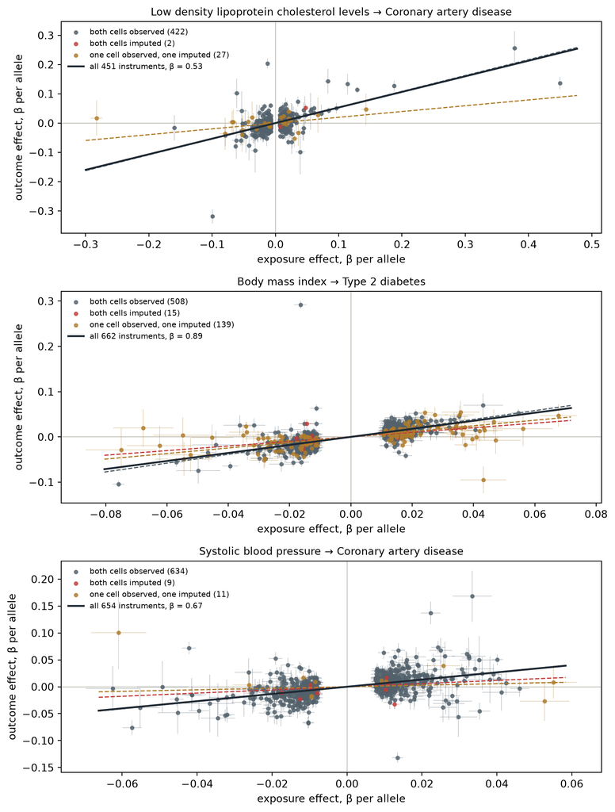

Per-instrument exposure (x) and outcome (y) effects for the three pairs, coloured by whether each cell was observed or filled in by Reference Completion, with ±1 se bars kept light. The solid line is the all-instrument IVW slope through the origin; each dashed line, in its stratum’s colour, is that stratum’s own IVW slope where a stratum has an estimate.

**Low density lipoprotein cholesterol levels → Coronary artery disease** — `GCST90239658` → `GCST003116`, 451 instruments of which 29 imputed

| Stratum | n | IVW β | se (random effects) | se (fixed) | p |
| --- | --- | --- | --- | --- | --- |
| both cells observed | 422 | +0.542 | 0.0423 | 0.0243 | 1.9e-37 |
| both cells imputed | 2 | — | — | — | no estimate (< 3 instruments) |
| one cell observed, one imputed | 27 | +0.198 | 0.1257 | 0.1257 | 0.12 |

**Body mass index → Type 2 diabetes** — `GCST90029007` → `GCST006867`, 662 instruments of which 154 imputed

| Stratum | n | IVW β | se (random effects) | se (fixed) | p |
| --- | --- | --- | --- | --- | --- |
| both cells observed | 508 | +0.966 | 0.0516 | 0.0231 | 2.7e-78 |
| both cells imputed | 15 | +0.506 | 0.2133 | 0.1538 | 0.018 |
| one cell observed, one imputed | 139 | +0.613 | 0.0622 | 0.0456 | 6.6e-23 |

**Systolic blood pressure → Coronary artery disease** — `GCST90310294` → `GCST003116`, 654 instruments of which 20 imputed

| Stratum | n | IVW β | se (random effects) | se (fixed) | p |
| --- | --- | --- | --- | --- | --- |
| both cells observed | 634 | +0.680 | 0.0487 | 0.0308 | 2.4e-44 |
| both cells imputed | 9 | +0.295 | 0.4689 | 0.2798 | 0.53 |
| one cell observed, one imputed | 11 | +0.141 | 0.3428 | 0.2788 | 0.68 |

This is what summary-statistic imputation predicts. An imputed z is the expected value given the observed variants around it, shrunk towards zero by the imputation’s uncertainty, so an instrument with an imputed cell understates its effect, and most imputed instruments here have an observed exposure and an imputed outcome. That is why the table at the top of this section takes the both-observed instruments as its estimate and shows the all-instrument one beside it.

**WarningThis is not a causal estimate**

The three rows above are positive controls for the query path, not findings. Their job is to show that instruments can be found, that effect signs survive the build’s allele orientation, and that standard errors propagate through a query. The estimates come out in the expected direction and magnitude, which is what a correct pipeline predicts.

They are not an epidemiological result:

- **Distance pruning is not LD clumping.** Instruments are pruned by distance rather than by linkage disequilibrium, so variants in LD survive together and the weighted IVW treats them as independent. That is part of what the inflated Cochran’s Q is measuring.
- **Some pairs share samples.** Where the two GWAS overlap, an instrument’s effects on exposure and outcome are correlated and the IVW variance is wrong.
- **No sensitivity analysis.** There is no pleiotropy-robust estimator, no MR-Egger intercept, no Steiger filtering and no leave-one-out. A causal claim needs all of them, against properly clumped and harmonised data.

What the Store contributes here is that all three pairs read one coordinate system, in one process, in seconds.

### Regional windows

Three ±500 kb windows, one per gene, each read for the single Analysis that owns the trait: every shared-axis variant in the window is looked up through the Hybrid path, so a plot holds panel cells and off-axis cells together. Grey is a cell the source reported, red one Reference Completion filled in, and a triangle one only the Ragged Overflow holds.

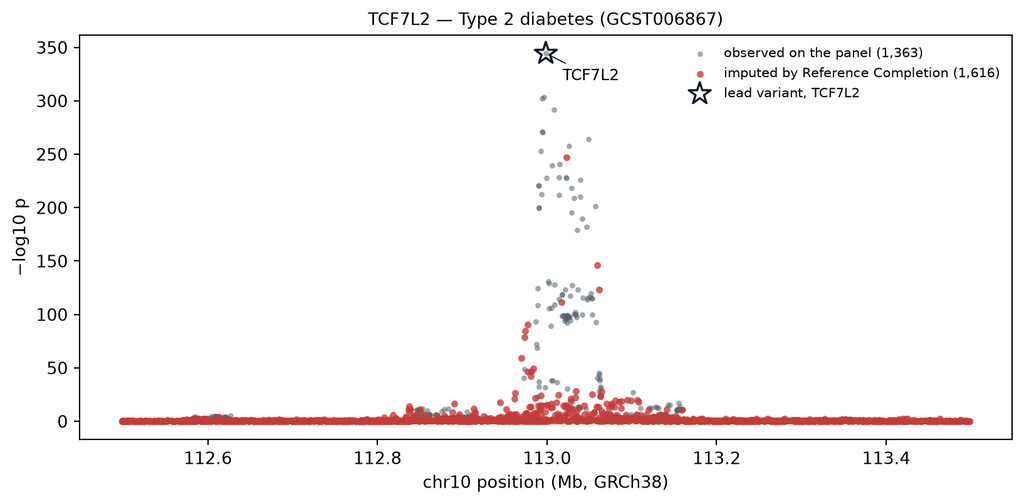

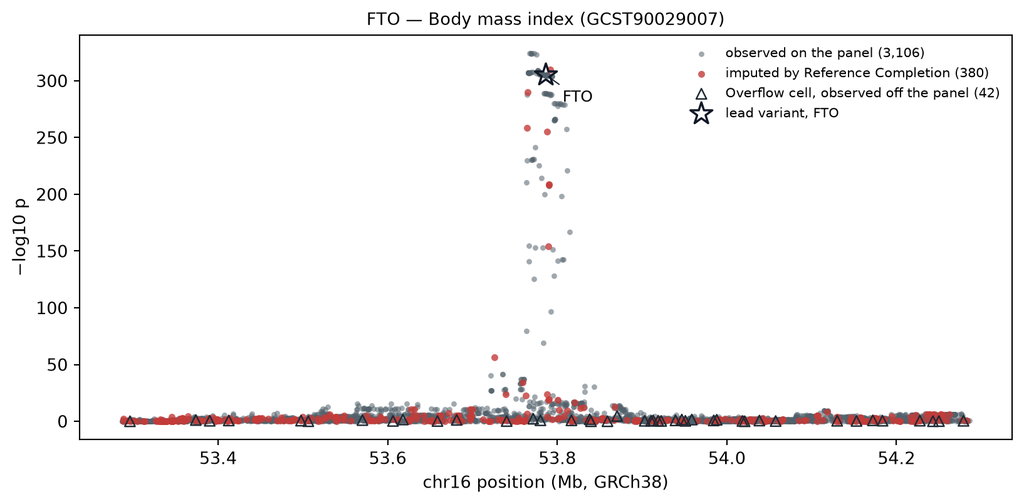

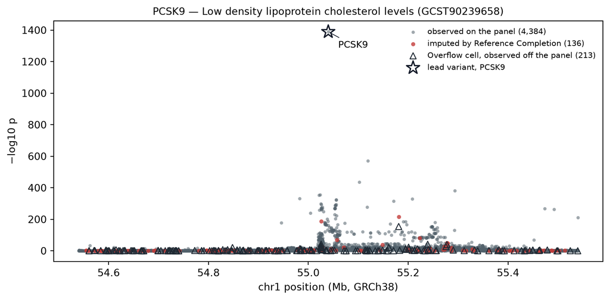

| Gene | Analysis | Window | Observed rows | Imputed rows | Elapsed |
| --- | --- | --- | --- | --- | --- |
| **TCF7L2** | `GCST006867` Type 2 diabetes | chr10:112,498,590–113,498,590 | 1,363 | 1,616 | 6.26 s |
| **FTO** | `GCST90029007` Body mass index | chr16:53,286,615–54,286,615 | 3,148 | 380 | 8.61 s |
| **PCSK9** | `GCST90239658` Low density lipoprotein cholesterol levels | chr1:54,539,974–55,539,974 | 4,597 | 136 | 11.00 s |

## Provenance

| Field | Value |
| --- | --- |
| Artifact | `opengwasdb_ogs00011_hybrid_benchmark.json` |
| Harness | `benchmarks/benchmark_ogs00011_hybrid.py` |
| Store | `/data/opengwasdb/stores/OGS-00011/store.opengwasdb` |
| opengwasdb commit | `40446bb0` |
| Measured at | 2026-11-25T09:25:52.267152+00:00 |
| opengwasdb import path | `/data/opengwasdb/work/issue478-bench/tree/opengwasdb` |
| opengwasdb fingerprint | `014c542162dd45e6d32e5e19d18e4f48415ae1316a27474c84846d02b088e2bd` |

The command that produced the artifact, run from the repository root:

```
pixi run -e dev python benchmarks/benchmark_ogs00011_hybrid.py
    --store /data/opengwasdb/stores/OGS-00011/store.opengwasdb
    --manifest /data/opengwasdb/stores/OGS-00011/work/analyses.tsv
    --records /data/opengwasdb/stores/OGS-00011/records
    --output docs/benchmark-output/opengwasdb_ogs00011_hybrid_benchmark.json
```

The commit names the checkout’s `HEAD` when the run finished; the fingerprint is a sha256 over the package’s Python sources, so it names the code itself and would differ if the tree had been edited after the commit. Every figure on this page was read from the artifact at render time — the page holds no copy of the measurement.